# final_submission

## Exploring Email domains

While we see a lot of NaN, it's also clear that consolidating related domains (e.g. yahoo.com and yahoo.com.mx are both owned by yahoo) will strengthen the owner domains in the data

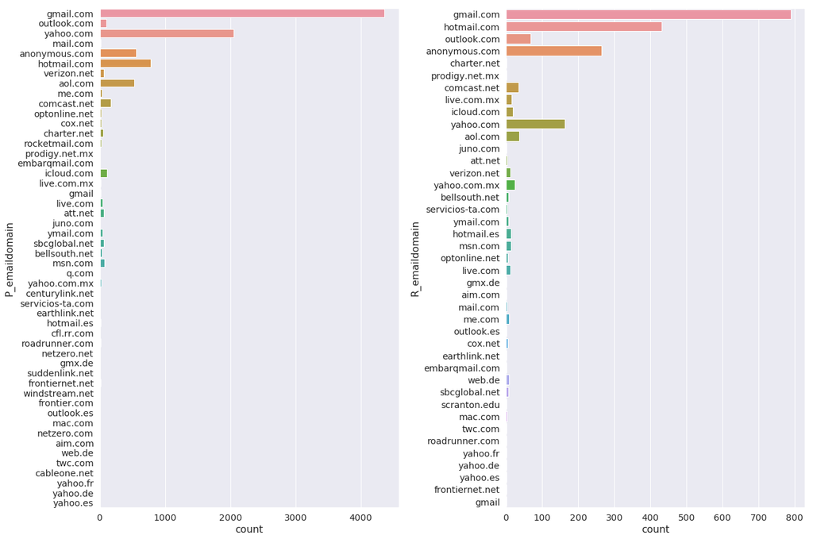

```python
f, axes = plt.subplots(1, 2, figsize=(18, 12))

sns.set(color_codes=True)
p_email = sns.countplot(y='P_emaildomain', data=train_df, ax=axes[0])
r_email = sns.countplot(y='R_emaildomain', data=train_df, ax=axes[1])
plt.tight_layout()
```

```python
# email domain binning - binning related email domains
# per https://www.kaggle.com/c/ieee-fraud-detection/discussion/100499#latest_df-579654
# it's ok just to bin R_emaildomain and P_emaildomain

emails = {'gmail': 'google', 'att.net': 'att', 'twc.com': 'spectrum', 'scranton.edu': 'other', 'optonline.net': 'other', 'hotmail.co.uk': 'microsoft', 'comcast.net': 'other', 'yahoo.com.mx': 'yahoo', 'yahoo.fr': 'yahoo', 'yahoo.es': 'yahoo', 'charter.net': 'spectrum', 'live.com': 'microsoft', 'aim.com': 'aol', 'hotmail.de': 'microsoft', 'centurylink.net': 'centurylink', 'gmail.com': 'google', 'me.com': 'apple', 'earthlink.net': 'other', 'gmx.de': 'other', 'web.de': 'other', 'cfl.rr.com': 'other', 'hotmail.com': 'microsoft', 'protonmail.com': 'other', 'hotmail.fr': 'microsoft', 'windstream.net': 'other', 'outlook.es': 'microsoft', 'yahoo.co.jp': 'yahoo', 'yahoo.de': 'yahoo', 'servicios-ta.com': 'other', 'netzero.net': 'other', 'suddenlink.net': 'other', 'roadrunner.com': 'other', 'sc.rr.com': 'other', 'live.fr': 'microsoft', 'verizon.net': 'yahoo', 'msn.com': 'microsoft', 'q.com': 'centurylink', 'prodigy.net.mx': 'att', 'frontier.com': 'yahoo', 'anonymous.com': 'other', 'rocketmail.com': 'yahoo', 'sbcglobal.net': 'att', 'frontiernet.net': 'yahoo', 'ymail.com': 'yahoo', 'outlook.com': 'microsoft', 'mail.com': 'other', 'bellsouth.net': 'other', 'embarqmail.com': 'centurylink', 'cableone.net': 'other', 'hotmail.es': 'microsoft', 'mac.com': 'apple', 'yahoo.co.uk': 'yahoo', 'netzero.com': 'other', 'yahoo.com': 'yahoo', 'live.com.mx': 'microsoft', 'ptd.net': 'other', 'cox.net': 'other', 'aol.com': 'aol', 'juno.com': 'other', 'icloud.com': 'apple'}
us_emails = ['gmail', 'net', 'edu']

for c in ['P_emaildomain', 'R_emaildomain']:
    train_df[c + '_bin'] = train_df[c].map(emails)
    test_df[c + '_bin'] = test_df[c].map(emails)

    train_df[c + '_suffix'] = train_df[c].map(lambda x: str(x).split('.')[-1])
    test_df[c + '_suffix'] = test_df[c].map(lambda x: str(x).split('.')[-1])

    train_df[c + '_suffix'] = train_df[c + '_suffix'].map(lambda x: x if str(x) not in us_emails else 'us')
    test_df[c + '_suffix'] = test_df[c + '_suffix'].map(lambda x: x if str(x) not in us_emails else 'us')
```

```python
for c1, c2 in train_df.dtypes.reset_index().values:
    if c2=='O':
        train_df[c1] = train_df[c1].map(lambda x: str(x).lower())
        test_df[c1] = test_df[c1].map(lambda x: str(x).lower())
```

## Explore the card columns

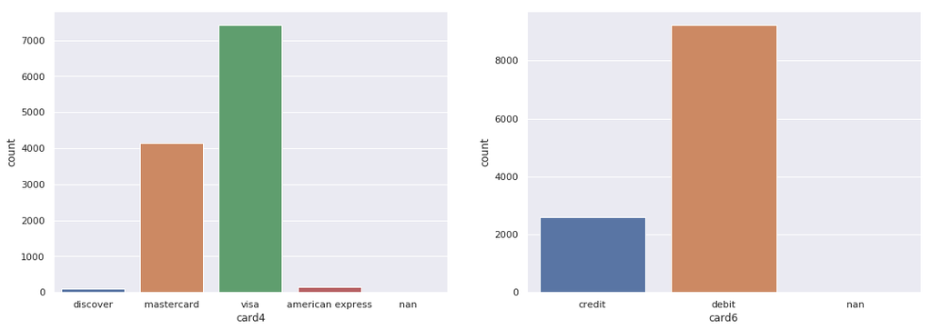

```python
# Plot cards 4 and 6 first - they are non-float64/the rest are float64
# Cards 4 and 6 may be some kind of card type but that's all we know

f, axes = plt.subplots(1, 2, figsize=(18, 6))
sns.set(color_codes=True)
card4 = sns.countplot(x='card4', data=train_df, ax=axes[0])
card6 = sns.countplot(x='card6', data=train_df, ax=axes[1])
```

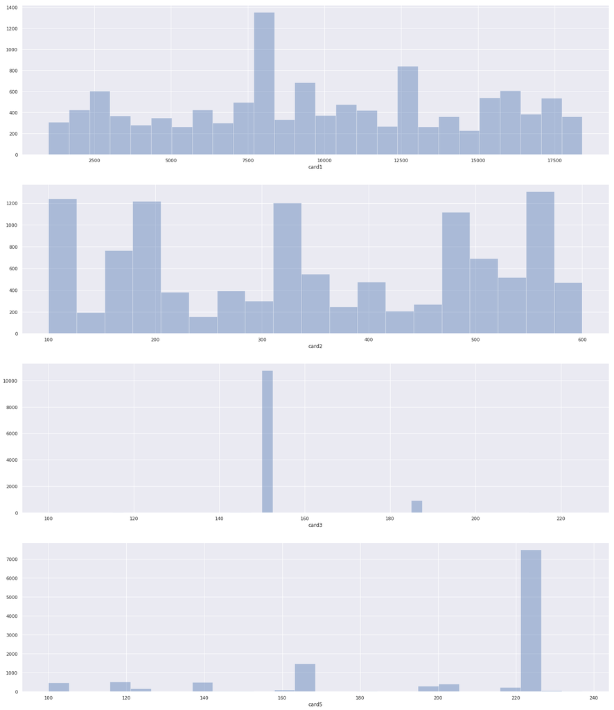

```python
# These cards are encoded as float64.
# Given there are many possible values. we
# will plot this a distributions (x a# xis is just an id)
# Cards 3/5 have the largest outliers

f, axes = plt.subplots(4, 1, figsize=(25, 30))

c1 = sns.distplot(train_df.card1,kde=False, ax=axes[0])
c2 = sns.distplot(train_df.card2.dropna(),kde=False, ax=axes[1])
c3 = sns.distplot(train_df.card3.dropna(),kde=False, ax=axes[2])
c5 = sns.distplot(train_df.card5.dropna(),kde=False, ax=axes[3])
```

## At this point, convinced of our strategy to:

-Use a deep learning NN

-So we don't see a point of further exploring the addr1, M, synthetic 'V' variables

-We'll let the NN work with all this

## Look for columns with missing data

```python
# thanks to https://www.kaggle.com/ysjf13/cis-fraud-detection-visualize-feature-engineering

null_cols = train_df.isnull().sum()/len(train_df) * 100
null_cols = null_cols.drop(null_cols[null_cols == 0].index).sort_values(ascending=False)[:500]

missing_data = pd.DataFrame({'Top columns with missing data': null_cols})
missing_data.head()
missing_data.shape
```

```
(340, 1)
```

## Find and remove useless columns

If many (defined below) column values are the same, remove the column If many (defined below) column values are null, remove the column

```python
null_val_threshold = 0.9
repeated_val_threshold = 0.9

def get_too_many_null_attr(data):
    many_null_cols = [col for col in data.columns if data[col].isnull().sum() / data.shape[0] > null_val_threshold]
    return many_null_cols

def get_too_many_repeated_val(data):
    big_top_value_cols = [col for col in train_df.columns if train_df[col].value_counts(dropna=False, normalize=True).values[0] > repeated_val_threshold]
    return big_top_value_cols

def get_useless_columns(data):
    too_many_null = get_too_many_null_attr(data)
    print("More than {} nulls: ".format(null_val_threshold) + str(len(too_many_null)))
    too_many_repeated = get_too_many_repeated_val(data)
    print("More than {} repeated values: ".format(repeated_val_threshold) + str(len(too_many_repeated)))
    cols_to_drop = list(set(too_many_null + too_many_repeated))
    cols_to_drop.remove('isFraud')
    return cols_to_drop

cols_to_drop = get_useless_columns(train_df)
train_df = train_df.drop(cols_to_drop, axis=1)
test_df = test_df.drop(cols_to_drop, axis=1)
```

```
More than 0.9 nulls: 16
More than 0.9 repeated values: 79
```

## Handle Numerical and Categorical

Categorizing some key variables available to us. We have numerical and categoricals.

```python
# approach based on
# https://www.kaggle.com/c/ieee-fraud-detection/discussion/100499#latest_df-579654
numerical = ["TransactionAmt", "nulls1", "dist1", "dist2"] + ["C" + str(i) for i in range(1, 15)] + \
            ["D" + str(i) for i in range(1, 16)] + \
            ["V" + str(i) for i in range(1, 340)]
categorical = ["ProductCD", "card1", "card2", "card3", "card4", "card5", "card6", "addr1", "addr2",
               "P_emaildomain_bin", "P_emaildomain_suffix", "R_emaildomain_bin", "R_emaildomain_suffix",
               "P_emaildomain", "R_emaildomain",
              "DeviceInfo", "DeviceType"] + ["id_0" + str(i) for i in range(1, 10)] +\
                ["id_" + str(i) for i in range(10, 39)] + \
                 ["M" + str(i) for i in range(1, 10)]
```

We already dropped a lot of these features because in some trial and error it was shown that these caused rapid overfitting for some reason or otherwise introduced unnecessary noise into the data. We will make sure we only list the features we actually have still in the df now

```python
numerical = [col for col in numerical if col in train_df.columns]
categorical = [col for col in categorical if col in train_df.columns]
```

## Handling outliers and NaNs

NN don't play well with nans -> fill 0 in numerical columns Replace outliers with medians

```python
def replace_nan(in_df):
    for x in list(in_df.columns.values):
        if x in numerical:
            in_df[x] = in_df[x].fillna(0)
            median = float(in_df[x].median())
            std =  float(in_df[x].std())
            in_df[x] = np.where( (in_df[x] - median) > 4*std, median, in_df[x])
    return in_df
train_df=replace_nan(train_df)
test_df=replace_nan(test_df)
```

## Label Encoding

```python
# Label Encoding
category_counts = {}
for f in categorical:
    train_df[f] = train_df[f].replace("nan", "other")
    train_df[f] = train_df[f].replace(np.nan, "other")
    test_df[f] = test_df[f].replace("nan", "other")
    test_df[f] = test_df[f].replace(np.nan, "other")
    lbl = preprocessing.LabelEncoder()
    lbl.fit(list(train_df[f].values) + list(test_df[f].values))
    train_df[f] = lbl.transform(list(train_df[f].values))
    test_df[f] = lbl.transform(list(test_df[f].values))
    category_counts[f] = len(list(lbl.classes_)) + 1
```

```python
from sklearn.preprocessing import StandardScaler
```

## Numerical Scaling

Scale the data so that it will be in a more NN friendly format. First we will do log1p for any values that are above 100 and not below 0. This is in order to scale down any numerical variables that might have some extremely high values that hurts the statistics of the standard scaler

https://www.kaggle.com/kernels/scriptcontent/18546295/download#Keras-NN-Starter-Kernel

https://www.kaggle.com/vaishvik25/keras-nn

The idea came from other kernels above: the use of standard scaler makes sense so that the values have a normal mean and std. This makes the NN converge signficantly faster + prevents crashes/freezes/hangs.

```python
for column in numerical:
    scaler = StandardScaler()
    if train_df[column].max() > 100 and train_df[column].min() >= 0:
        train_df[column] = np.log1p(train_df[column])
        test_df[column] = np.log1p(test_df[column])
    scaler.fit(np.concatenate([train_df[column].values.reshape(-1,1), test_df[column].values.reshape(-1,1)]))
    train_df[column] = scaler.transform(train_df[column].values.reshape(-1,1))
    test_df[column] = scaler.transform(test_df[column].values.reshape(-1,1))
```

```python
target = 'isFraud'
```

```python
# split data - test_size of 20% size - will be used to input validation data
tr_df, val_df = train_test_split(train_df, test_size = 0.2, random_state = 12, shuffle = True)
```

Grabbing the features we want to pass into the neural network

```python
def get_input_features(df):
    X = {'numerical':np.array(df[numerical])}
    for cat in categorical:
        X[cat] = np.array(df[cat])
    return X
```

## Neural Network Model Design

The neural network will use the embedding layer for categoricals and the numericals will go through feed forward dense layers.

We create our embedding layers so that: (i) we have as many rows as categories (ii) and the dimension of the embedding is the log1p + 1 of the number of categories. So this means that categorical variables with very high cardinality will have more dimensions but not signficantly more so the information will still be compressed down

We will then pass the embeddings through a spatial dropout layer which will drop dimensions within the embedding across batches and then flatten and concatenate. Then we will concatenate this to the numerical features and then add some more dense layers after.

```python
category_counts
```

```
{'DeviceInfo': 1143,
 'DeviceType': 4,
 'M1': 4,
 'M2': 4,
 'M3': 4,
 'M4': 5,
 'M5': 4,
 'M6': 4,
 'M7': 4,
 'M8': 4,
 'M9': 4,
 'P_emaildomain': 61,
 'P_emaildomain_bin': 10,
 'P_emaildomain_suffix': 10,
 'ProductCD': 6,
 'R_emaildomain': 62,
 'R_emaildomain_bin': 10,
 'R_emaildomain_suffix': 10,
 'addr1': 128,
 'card1': 9396,
 'card2': 502,
 'card4': 6,
 'card5': 92,
 'card6': 5,
 'id_01': 59,
 'id_02': 36269,
 'id_05': 81,
 'id_06': 99,
 'id_09': 32,
 'id_10': 39,
 'id_11': 208,
 'id_12': 4,
 'id_13': 33,
 'id_14': 26,
 'id_15': 5,
 'id_16': 4,
 'id_17': 83,
 'id_19': 418,
 'id_20': 295,
 'id_28': 4,
 'id_29': 4,
 'id_30': 80,
 'id_31': 123,
 'id_32': 6,
 'id_33': 208,
 'id_34': 5,
 'id_35': 4,
 'id_36': 4,
 'id_37': 4,
 'id_38': 4}
```

# Create model- basic model with special handling of categoricals

Use Dropout to prevent overfitting use an embedding layer; vectorize all inputs -> flatten them use log1p to better support small input values

Neural Network Model Details

We will then pass the embeddings through a spatial dropout layer which will drop dimensions within the embedding across batches and then flatten and concatenate. Then we will concatenate this to the numerical features and add some more dense layers after.

# Activation functions

I used relu for efficiency with sigmoid in the end to ensure that the output layer doesn't blow up+to mitigate the "vanishing" gradient issue with relu. Note: I tried softmax for the output layer as advised by the reviewer of my project proposal. Unfortunately, that yielded AOC of 0.5 so I dropped it in favor of sigmoid. Thank you for the input anyway.

```python
from keras.layers import Concatenate, Input, Dense, Embedding, Flatten, Dropout, BatchNormalization, SpatialDropout1D
from keras.callbacks import ModelCheckpoint, ReduceLROnPlateau
from sklearn.preprocessing import MinMaxScaler,StandardScaler
from keras.models import Sequential
from keras.layers import Dense,Dropout
import gc, datetime, random
from copy import deepcopy

from keras.models import Model
from keras.optimizers import  Adam
import keras.backend as k

def make_model():
    k.clear_session()
    categorical_inputs = []
    for cat in categorical:
        categorical_inputs.append(Input(shape=[1], name=cat))

    categorical_embeddings = []
    for i, cat in enumerate(categorical):
        categorical_embeddings.append(
            Embedding(category_counts[cat], int(np.log1p(category_counts[cat]) + 1), name = cat + "_embed")(categorical_inputs[i]))

    categorical_logits = Concatenate(name = "categorical_conc")([Flatten()(SpatialDropout1D(.1)(cat_emb)) for cat_emb in categorical_embeddings])

    numerical_inputs = Input(shape=[tr_df[numerical].shape[1]], name = 'numerical')
    numerical_logits = Dropout(.1)(numerical_inputs)


    x = Concatenate()([
        categorical_logits,
        numerical_logits,
    ])

    x = Dense(200, activation = 'relu')(x)
    x = Dropout(.2)(x)
    x = Dense(100, activation = 'relu')(x)
    x = Dropout(.2)(x)
    out = Dense(1, activation = 'sigmoid')(x)


    model = Model(inputs=categorical_inputs + [numerical_inputs],outputs=out)
    loss = "binary_crossentropy"
    model.compile(optimizer=Adam(lr = 0.005, amsgrad=False), loss = loss)
    return model
```

We will then extract the features we actually want to pass to the NN

```python
from sklearn.metrics import roc_auc_score
```

## Get benchmark auc - make basic model and run

```python
X_train = get_input_features(tr_df)
X_valid = get_input_features(val_df)
X_test = get_input_features(test_df)
y_train = tr_df[target]
y_valid = val_df[target]
model = make_model()

hist = model.fit(X_train, y_train, validation_data = (X_valid,y_valid), batch_size = 8000, epochs = 20, verbose = 1)
valid_preds = model.predict(X_valid, batch_size = 8000, verbose = True)
score = roc_auc_score(y_valid, valid_preds)

print("ROC AUC score is = {}".format(score))
```

[output not shown]

```
Train on 9471 samples, validate on 2368 samples
ROC AUC score is = 0.8428836317135551
```

```python
hist = model.fit(X_valid,y_valid, batch_size = 8000, epochs = 3, verbose = 1)
```

```python
predictions = model.predict(X_test, batch_size = 2000, verbose = True)
```

```python
pd.DataFrame(valid_preds).describe()
```

|  | 0 |
| --- | --- |
| count | 2368.000000 |
| mean | 0.029450 |
| std | 0.057569 |
| min | 0.000000 |
| 25% | 0.004302 |
| 50% | 0.014106 |
| 75% | 0.031860 |
| max | 0.918994 |

```python
pd.DataFrame(predictions).describe()
```

|  | 0 |
| --- | --- |
| count | 202676.000000 |
| mean | 0.008063 |
| std | 0.019118 |
| min | 0.000000 |
| 25% | 0.000096 |
| 50% | 0.001836 |
| 75% | 0.009093 |
| max | 0.710936 |

```python
print(sample_submission.shape)
sample_submission['isFraud'] = predictions
sample_submission.to_csv('submission_JM.csv')
```

```
(202676, 1)
```